# Variant Pipeline Tutorial

JT McCrone

July 24, 2015

We’ll load the needed packages. (You may have to install these)

```r
require(ggplot2)
theme_set(new = theme_classic(base_size = 20))  # to make nice plots
require(Biostrings)
require(plyr)
require(knitr)
opts_chunk$set(fig.width = 6, fig.height = 6, message = F, fig.align = "center")
```

## Coverage

Our first step is to read in the data.

```r
cov.df <- read.csv("../worked_data/deepSNV/all.coverage.csv", stringsAsFactor = F)
cov.df$chr[cov.df$chr == "N_A"] <- as.character("NA")

head(cov.df)
```

```
##   coverage concat.pos chr chr.pos    Id
## 1      489          1 PB2       1 HA_22
## 2      518          2 PB2       2 HA_22
## 3      519          3 PB2       3 HA_22
## 4      534          4 PB2       4 HA_22
## 5      529          5 PB2       5 HA_22
## 6      538          6 PB2       6 HA_22
```

Initially we can look at the coverage for each sample by segment.

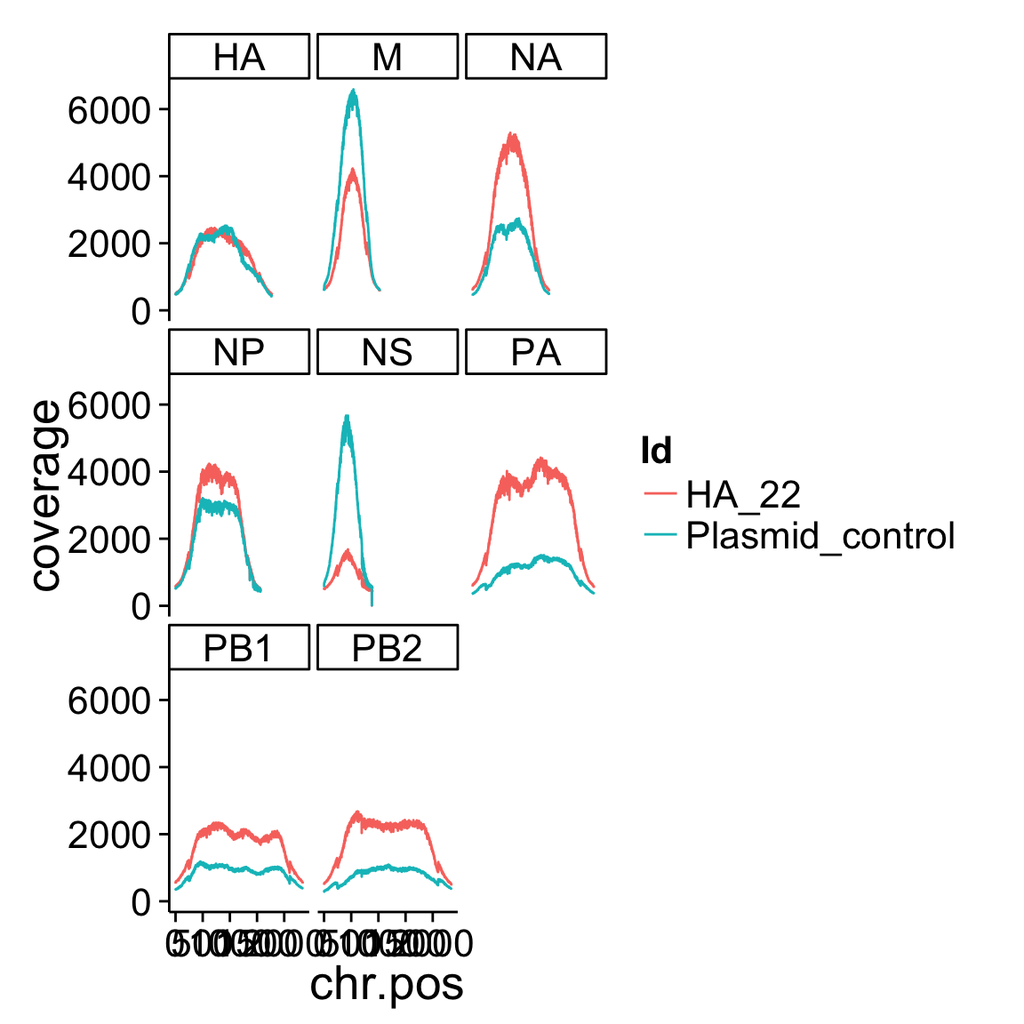

```r
seg.cov <- ggplot(cov.df, aes(x = chr.pos, y = coverage, color = Id)) + geom_line() +
    facet_wrap(~chr)
seg.cov
```

An easier way to view multiple samples is to concatenate the segments. The concatenated positions also come in the output.

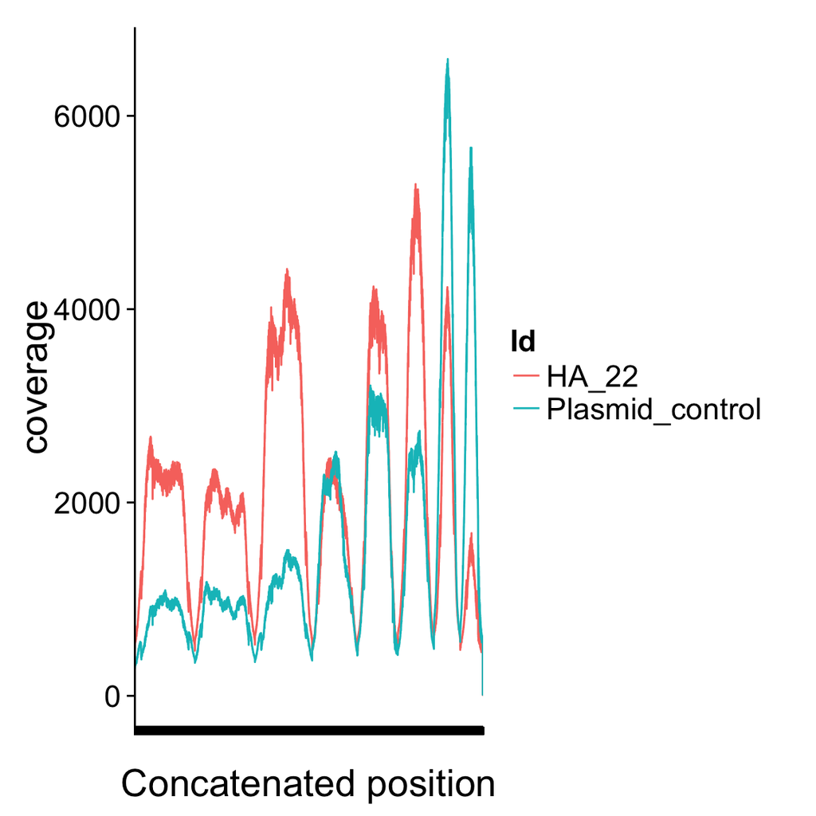

```r
concat.cov <- ggplot(cov.df, aes(x = concat.pos, y = coverage, color = Id)) +
    geom_line() + xlab("Concatenated position") + scale_x_discrete(labels = "")
concat.cov
```

The segements are in the same order as they appear in the fasta file. (In this case it is the normal flu order)

But this can be crazy with many samples so often is is useful to do a sliding window mean on each sample and combine the samples together using a box plot.

### If you only want boxplots start here

Here we make and apply a function for the sliding window.

```r
# funciton to make the sliding windows dapted from
# http://coleoguy.blogspot.com/2014/04/sliding-window-analysis.html
slideFunct <- function(data, window, step) {
    coverage <- data$coverage
    pos <- data$chr.pos
    # c.pos<-data$concat.pos
    total <- length(coverage)
    spots <- seq(from = 1, to = (total - window), by = step)
    result <- data.frame(mean = rep(F, times = length(spots)), pos = rep(F,
        times = length(spots)))
    for (i in 1:length(spots)) {
        result$mean[i] <- mean(coverage[spots[i]:(spots[i] + window)])
        result$pos[i] <- mean(pos[spots[i]:(spots[i] + window)])
        # result$concat.pos[i]<-mean(c.pos[spots[i]:(spots[i]+window)])
    }
    return(result)
}


wind <- 100  # window
step <- 100  #step size
cov.slid.df <- ddply(cov.df, ~Id + chr, function(x) slideFunct(x, window = wind,
    step = step))  # applies the sliding window
head(cov.slid.df)
```

```
##      Id chr      mean pos
## 1 HA_22  HA  555.0792  51
## 2 HA_22  HA  803.2475 151
## 3 HA_22  HA 1109.4752 251
## 4 HA_22  HA 1557.3267 351
## 5 HA_22  HA 1994.9802 451
## 6 HA_22  HA 2269.6040 551
```

And now we’ll add the concatenated genome position.

```r
## Getting some info about the genome from the reference fasta.
reference.fasta<-"../data/reference/wsn33_wt_plasmid.fa"
segments <- fasta.info(reference.fasta)
regions.bed <- data.frame(chr = gsub("[ ].*","", names(segments)), start=1, stop=segments, row.names=NULL)
regions.bed<-mutate(regions.bed,chr=as.character(chr))
regions.bed<-mutate(regions.bed,chr=gsub("N_A","NA",chr)) # rename N_A segment to NA


##setting up information to concatenate the genome.

prior.seg.length<-c()
for(k in 1:length(regions.bed$chr)){
  prior.seg.length[k]<-sum(regions.bed$stop[1:k])  # the end positions of each segment relative to one sequence not including the trimming step
}
prior.seg.length<-c(0,prior.seg.length)


cov.slid.df<-mutate(cov.slid.df, # the concatenated position relative to the usual order
                    concat.pos=pos+prior.seg.length[match(chr,regions.bed$chr)]) # position is relative to each segement
head(cov.slid.df)
```

```
##      Id chr      mean pos concat.pos
## 1 HA_22  HA  555.0792  51       6968
## 2 HA_22  HA  803.2475 151       7068
## 3 HA_22  HA 1109.4752 251       7168
## 4 HA_22  HA 1557.3267 351       7268
## 5 HA_22  HA 1994.9802 451       7368
## 6 HA_22  HA 2269.6040 551       7468
```

And we plot using ggplot as before.

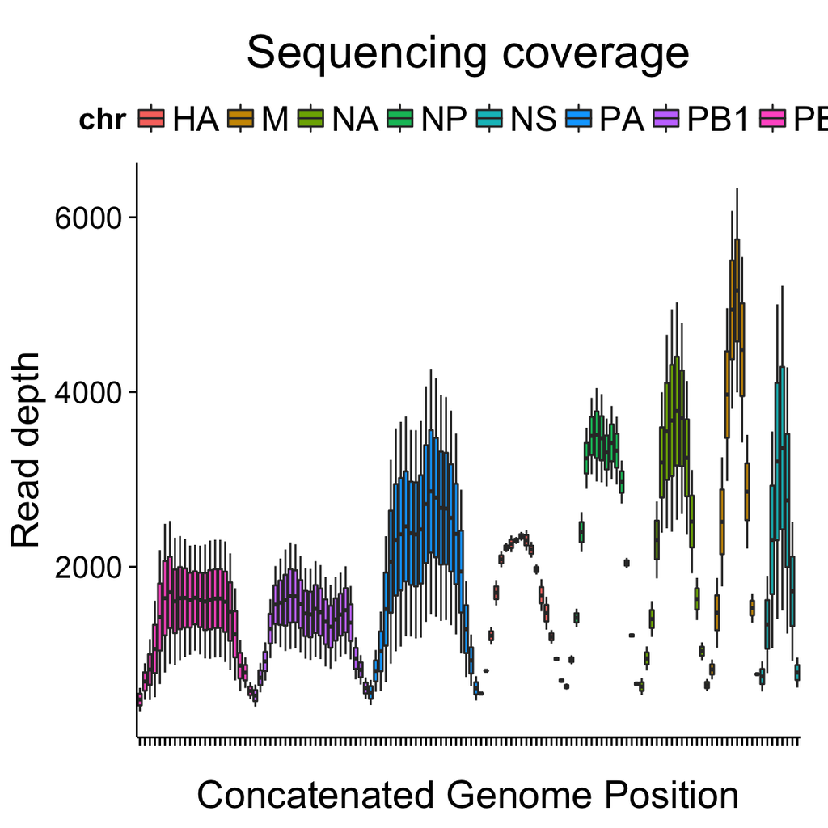

```r
## Plotting
cov.plot <- ggplot(cov.slid.df, mapping = aes(x = as.factor(concat.pos), y = mean,
    fill = chr)) + geom_boxplot()

cov.plot <- cov.plot + ggtitle("Sequencing coverage") + ylab("Read depth") +
    xlab("") + xlab("Concatenated Genome Position")
cov.plot <- cov.plot + scale_x_discrete(labels = "")  #+scale_y_continuous(limits=c(0,35000),breaks=c(10000,20000,30000))
cov.plot <- cov.plot + theme(axis.title.y = element_text(vjust = 1.2))
cov.plot <- cov.plot + theme(legend.position = "top", legend.text = element_text(size = 18))

cov.plot
```

# Filtering out False variants

```r
sum.df <- read.csv("../worked_data/Variants/all.sum.csv")
kable(sum.df, digits = 2)
```

| chr | pos | ref | var | p.val | freq.var | sigma2.freq.var | n.tst.fw | cov.tst.fw | n.tst.bw | cov.tst.bw | n.ctrl.fw | cov.ctrl.fw | n.ctrl.bw | cov.ctrl.bw | raw.p.val | Id | mutation | MapQ | Read_pos | Phred |
| --- | --- | --- | --- | --- | --- | --- | --- | --- | --- | --- | --- | --- | --- | --- | --- | --- | --- | --- | --- | --- |
| HA | 784 | A | G | 0.00 | 1.00 | 0 | 1100 | 1102 | 1176 | 1181 | 0 | 1195 | 0 | 1136 | 0 | HA_22 | HA_A784G | 41.57 | 122.89 | 36.61 |
| PA | 515 | A | G | 0.03 | 0.02 | 0 | 58 | 1909 | 7 | 1584 | 0 | 500 | 0 | 455 | 0 | HA_22 | PA_A515G | 40.98 | 3.55 | 33.38 |
| PA | 516 | T | G | 0.01 | 0.02 | 0 | 60 | 2023 | 8 | 1451 | 0 | 532 | 0 | 418 | 0 | HA_22 | PA_T516G | 41.03 | 2.96 | 33.37 |
| PA | 518 | A | G | 0.03 | 0.02 | 0 | 57 | 1977 | 7 | 1642 | 0 | 524 | 0 | 468 | 0 | HA_22 | PA_A518G | 41.34 | 8.39 | 34.00 |

To filter we simply use subset.

```r
filter.df <- subset(sum.df, p.val < 0.01 & Read_pos > 50 & Read_pos < 200)
kable(filter.df, digits = 2)
```

| chr | pos | ref | var | p.val | freq.var | sigma2.freq.var | n.tst.fw | cov.tst.fw | n.tst.bw | cov.tst.bw | n.ctrl.fw | cov.ctrl.fw | n.ctrl.bw | cov.ctrl.bw | raw.p.val | Id | mutation | MapQ | Read_pos | Phred |
| --- | --- | --- | --- | --- | --- | --- | --- | --- | --- | --- | --- | --- | --- | --- | --- | --- | --- | --- | --- | --- |
| HA | 784 | A | G | 0 | 1 | 0 | 1100 | 1102 | 1176 | 1181 | 0 | 1195 | 0 | 1136 | 0 | HA_22 | HA_A784G | 41.57 | 122.89 | 36.61 |

I’m not a betting man but I bet that’s the one we would suspect!

Enjoy!!